# Reproducible Research: Peer Assessment 1

## Loading and preprocessing the data

First, clean the workspace and load libraries

```r
rm(list=ls())
library(ggplot2)
library(chron)
```

Unzip and load the data

```r
unzip("activity.zip")
activity <- read.csv("activity.csv")
```

Now we process the data to filter out NAs and keep only complete cases

```r
activity.complete <- activity[complete.cases(activity),]
```

## What is mean total number of steps taken per day?

### 1. Calculate the total number of steps taken per day

First we sum up all the steps per day

```r
total_spd <- aggregate(activity.complete$steps,list(Date=activity.complete$date),sum)
names(total_spd)<-c("Date", "Steps_per_day")
```

The following plot shows the frequency of steps per day

```
## stat_bin: binwidth defaulted to range/30. Use 'binwidth = x' to adjust this.
```

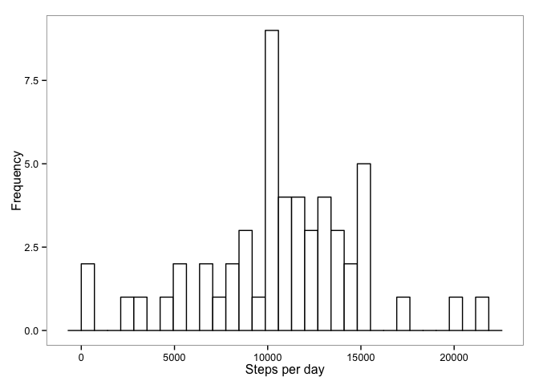

```r
ggplot(total_spd, aes(x=total_spd$Steps_per_day)) + geom_histogram(color = "black", fill = "white") + xlab("Steps per day") + ylab("Frequency")+ theme_bw() + theme(plot.background = element_blank(), panel.grid.major = element_blank(), panel.grid.minor = element_blank(),plot.title=element_text(size=15))
```

The mean total number of steps per day is:

```r
round(mean(total_spd$Steps_per_day, na.rm = T), digits = 3)
```

```
## [1] 10766.19
```

The median total number of steps per day is:

```r
round(median(total_spd$Steps_per_day, na.rm = T), digits = 3)
```

```
## [1] 10765
```

## What is the average daily activity pattern?

### Make a time series plot of the 5-minute interval (x-axis) and the average number of steps taken, averaged across all days (y-axis)

First we need to average the data attending to the time intervals

```r
aver_intervals<-aggregate(activity.complete$steps,list(fivemin=activity.complete$interval),mean)
names(aver_intervals) <- c("fivemin", "aversteps")
```

Now we can plot the average number of steps in a time series

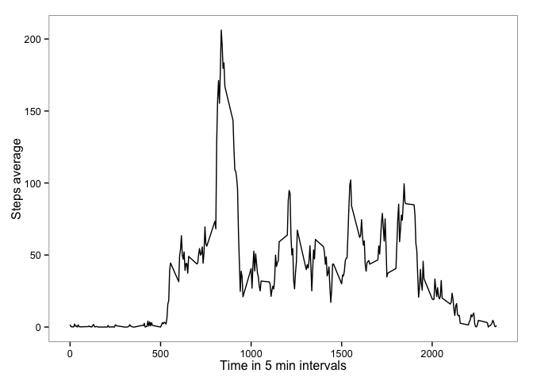

```r
ggplot(aver_intervals,aes(aver_intervals$fivemin,aver_intervals$aversteps)) +geom_line()  + xlab("Time in 5 min intervals") + ylab("Steps average")+ theme_bw() + theme(plot.background = element_blank(), panel.grid.major = element_blank(), panel.grid.minor = element_blank(),plot.title=element_text(size=15))
```

### Which 5-minute interval, on average across all the days in the dataset, contains the maximum number of steps?

The maximum number of averaged steps is

```r
max(aver_intervals$aversteps)
```

```
## [1] 206.1698
```

at the interval:

```r
interval<- subset(aver_intervals, aver_intervals$aversteps == max(aver_intervals$aversteps))
interval$fivemin
```

```
## [1] 835
```

## Imputing missing values

### Calculate and report the total number of missing values in the dataset

The number of rows with NAs in the dataset is:

```r
nrow(activity[is.na(activity$steps),])
```

```
## [1] 2304
```

### Devise a strategy for filling in all of the missing values in the dataset. Create a new dataset that is equal to the original dataset but with the missing data filled in.

```r
round(mean(activity$steps, na.rm = T))
```

```
## [1] 37
```

We apply this number of steps to the NA cases

```r
activity.fixed <-activity
for (i in 1:length(activity$steps)) if (is.na(activity$steps[i])) {
        activity.fixed$steps[i] <- round(mean(activity$steps, na.rm = T))
}
```

### Make a histogram of the total number of steps taken each day and Calculate and report the mean and median total number of steps taken per day.

With the fixed activity dataset The following plot shows the frequency of steps per day.

```
## stat_bin: binwidth defaulted to range/30. Use 'binwidth = x' to adjust this.
```

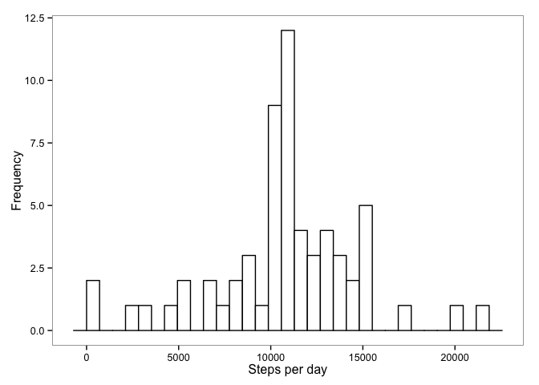

```r
total_spd.fix <- aggregate(activity.fixed$steps,list(Date=activity.fixed$date),sum)
names(total_spd.fix)<-c("Date", "Steps_per_day")
ggplot(total_spd.fix, aes(x=total_spd.fix$Steps_per_day)) + geom_histogram(color = "black", fill = "white") + xlab("Steps per day") + ylab("Frequency")+ theme_bw() + theme(plot.background = element_blank(), panel.grid.major = element_blank(), panel.grid.minor = element_blank(),plot.title=element_text(size=15))
```

The mean total number of steps per day in the fixed dataset is:

```r
round(mean(total_spd.fix$Steps_per_day, na.rm = T), digits = 3)
```

```
## [1] 10751.74
```

The median total number of steps per day in the fixed dataset is:

```r
round(median(total_spd.fix$Steps_per_day, na.rm = T), digits = 3)
```

```
## [1] 10656
```

## Are there differences in activity patterns between weekdays and weekends?

```r
weekend<-function(date){
        if (is.weekend(date)){
                'weekend'
        } else {
                'weekday'
        }
}

activity.fixed$day <- as.factor(sapply(activity.fixed$date,weekend))
```

Plot weekdays vs weekends data

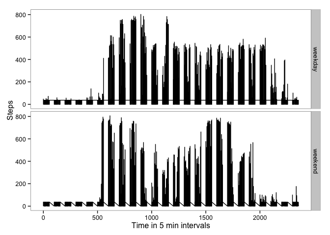

```r
aver_intervals<-aggregate(activity.fixed$steps,list(fivemin=activity.fixed$interval),mean)
names(aver_intervals) <- c("fivemin", "aversteps")

p<-ggplot(activity.fixed,aes(activity.fixed$interval,activity.fixed$steps)) +geom_line() +  xlab("Time in 5 min intervals") + ylab("Steps")+ theme_bw() + theme(plot.background = element_blank(), panel.grid.major = element_blank(), panel.grid.minor = element_blank(),plot.title=element_text(size=15))
p+facet_grid(day ~ .)
```